# Multiple linear models with purrr and broom

Casey Bates

2019-02-02

## Motivation

Utilize `tidyverse` tools and the `broom` package to generate numerous linear models to evaluate how well sale price is explained by square footage for home sales in Garfield County, Colorado. A dataset is publically available on the [Garfield County Assessor website](https://www.garfield-county.com/assessor/comparable-sales.aspx) that contains 2 years of data from summer 2014 through summer 2016.

## Outline

- Part 1: Exploring the dataset with `ggplot2`
  - Tidying wide datasets with `tidyr`
- Part 2: Many models with `purrr` and `broom`

## Part 1: Exploring the dataset with `ggplot2`

### Processing the data

- Import two Excel files:
  1. single family home sales, and
  2. condo & townhome sales
- Replace spaces in column names with underscore and make lowercase
- Rename some columns
- Add `classification` column to `single_family` dataset
  - Set all values to “Single Family”
- Use `bind_rows()` to combine the datasets into one
- Remove “Garage Only” observations

## Glimpse of the data

```r
glimpse(home_sales)
```

```
## Observations: 1,967
## Variables: 14
## $ account             <chr> "R340967", "R340073", "R112063", "R580140"...
## $ parcel_number       <chr> "239334401005", "239334200010", "239335100...
## $ reception           <chr> "879240", "870778", "869383", "857328", "8...
## $ sale_date           <chr> "6/29/2016", "11/24/2015", "10/13/2015", "...
## $ sale_price          <dbl> 650000, 560000, 2750000, 630500, 2800000, ...
## $ situs_address       <chr> "000066 N 2ND ST", "000276 10TH ST", "0008...
## $ location            <chr> "CARBONDALE", "CARBONDALE", "CARBONDALE", ...
## $ architectural_style <chr> "ONE STORY", "ONE STORY", "ONE STORY", "ON...
## $ year_built          <dbl> 1970, 1971, 2002, 1999, 2008, 1994, 1993, ...
## $ bedrooms            <dbl> 0, 1, 0, 1, 2, 1, 1, 1, 2, 2, 1, 2, 2, 2, ...
## $ baths               <dbl> 0.00, 1.00, 0.75, 1.00, 1.00, 1.00, 1.00, ...
## $ square_feet         <dbl> 0, 480, 680, 710, 764, 804, 825, 957, 960,...
## $ legal               <chr> "Section: 34 Township: 7 Range: 88 Subdivi...
## $ classification      <chr> "Single Family", "Single Family", "Single ...
```

## `ggplot2` package in R

- Created by Hadley Wickham
- Built on the “Grammar of Graphics” principles
- Core **tidyverse** package
- Every ggplot2 plot has 3 key components:
  - **Data**
  - **Aesthetic mappings** between variables and visuals
  - Layer(s) to describe how to render each observation (usually created with a **geom** function)

## Basic scatterplot

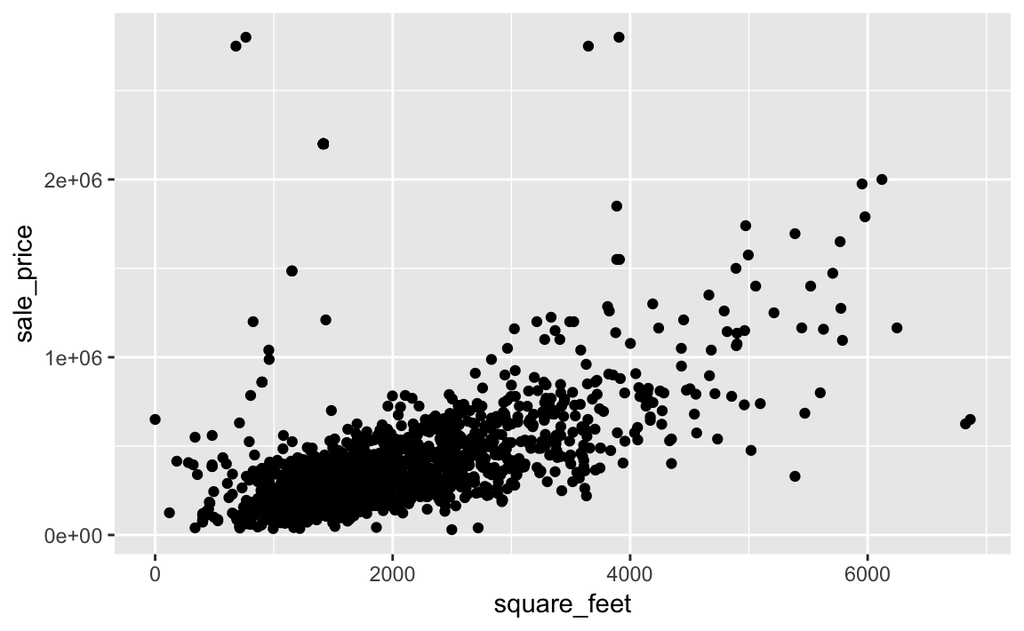

```r
ggplot(data = home_sales, aes(x = square_feet, y = sale_price)) +
  geom_point()
```

## Transparency and color by location

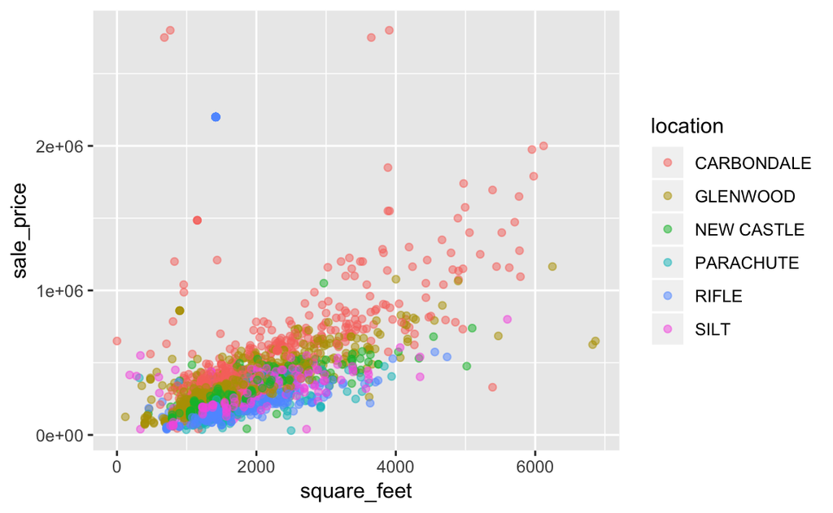

```r
ggplot(data = home_sales, aes(x = square_feet, y = sale_price, color = location)) +
  geom_point(alpha = 0.5)
```

## Zooming into sales above $1M

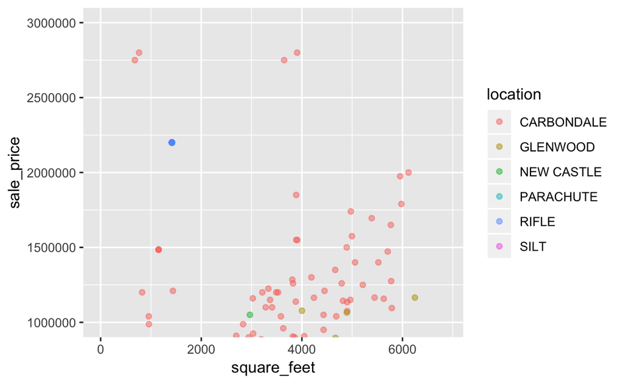

```r
ggplot(data = home_sales, aes(x = square_feet, y = sale_price, color = location)) +
  geom_point(alpha = 0.5) +
  coord_cartesian(ylim = c(1000000, 3000000))
```

## Add random noise with jitter

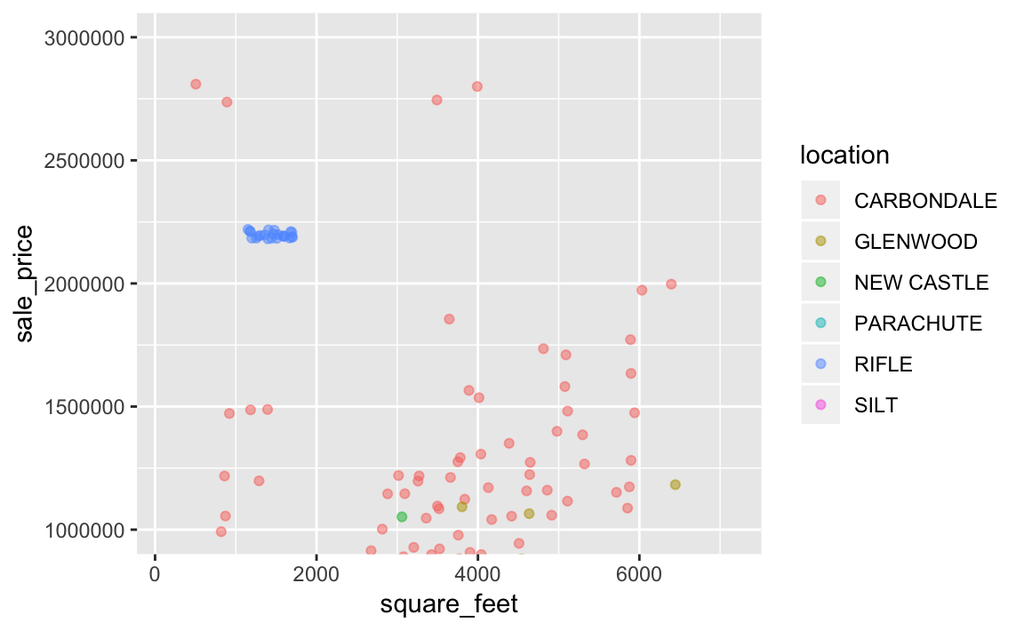

```r
ggplot(data = home_sales, aes(x = square_feet, y = sale_price, color = location)) +
  geom_jitter(alpha = 0.5, width = 300, height = 20000) +
  coord_cartesian(ylim = c(1000000, 3000000))
```

## Linear model: sale price vs. square ft.

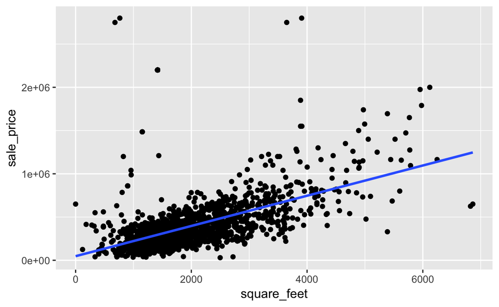

```r
ggplot(data = home_sales, aes(x = square_feet, y = sale_price)) +
  geom_point() +
  geom_smooth(method = "lm", se = FALSE) # Method set to lm for the linear model
```

## Linear model: sale price vs. square ft.

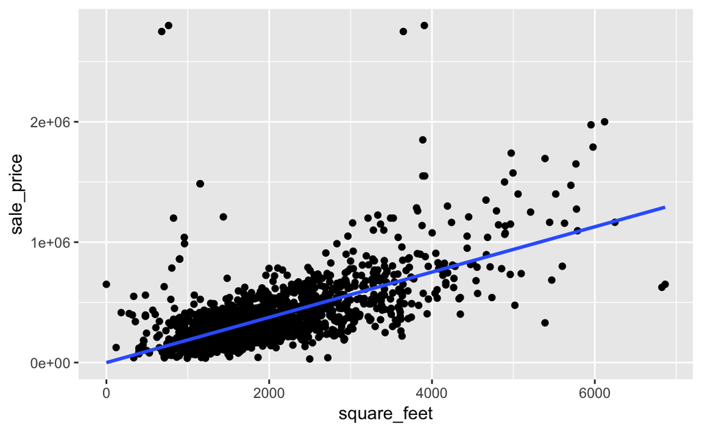

```r
ggplot(data = home_sales_fix, aes(x = square_feet, y = sale_price)) +
  geom_point() +
  geom_smooth(method = "lm", se = FALSE) # Method set to lm for the linear model
```

## Linear model: sale price vs. square feet

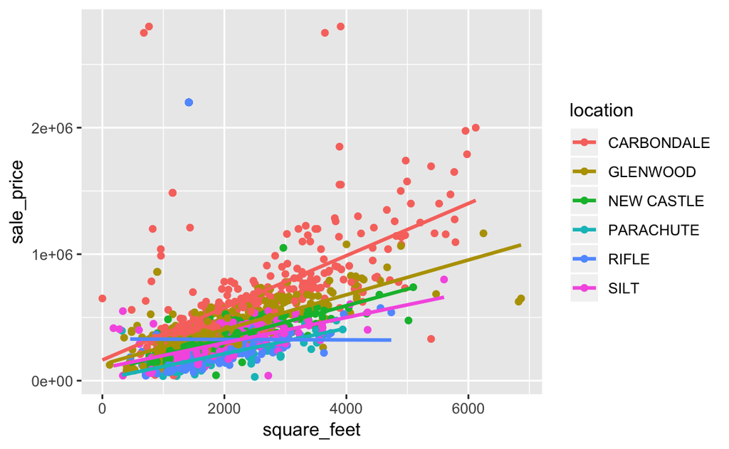

```r
ggplot(data = home_sales, aes(x = square_feet, y = sale_price, color = location)) +
  geom_point() +
  geom_smooth(method = "lm", se = FALSE) # Method set to lm for the linear model
```

## Linear model with errors removed

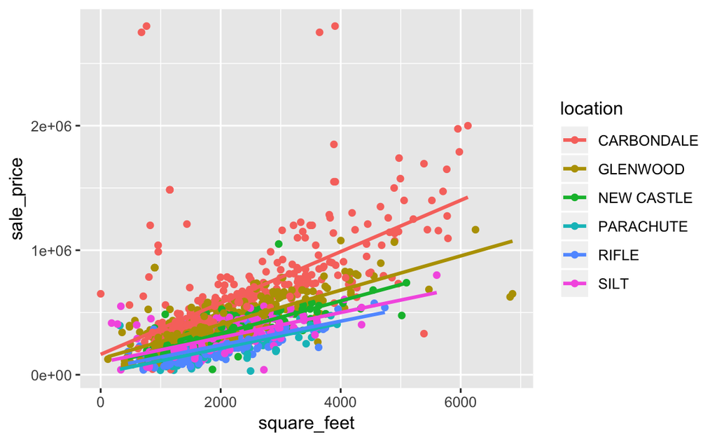

```r
ggplot(data = home_sales_fix, aes(x = square_feet, y = sale_price, color = location)) +
  geom_point() +
  geom_smooth(method = "lm", se = FALSE) # Method set to lm for the linear model
```

## Linear model facetted by location

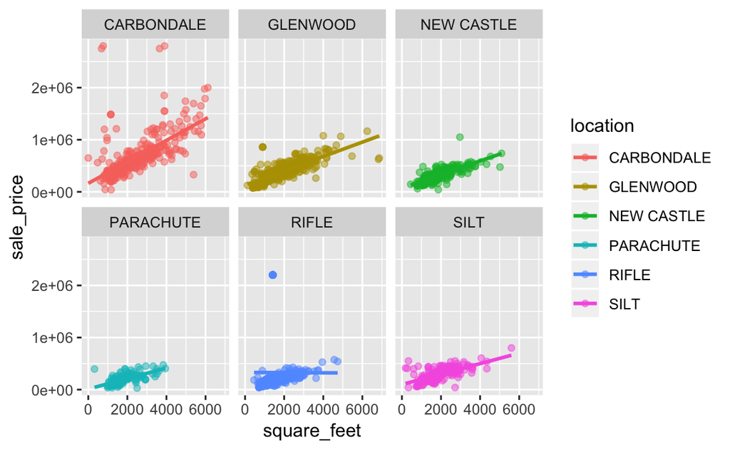

```r
ggplot(home_sales, aes(square_feet, sale_price, color = location)) +
  geom_point(alpha = 0.5) +
  geom_smooth(method = "lm", se = FALSE) +
  facet_wrap(~ location)
```

## Linear model facetted by location

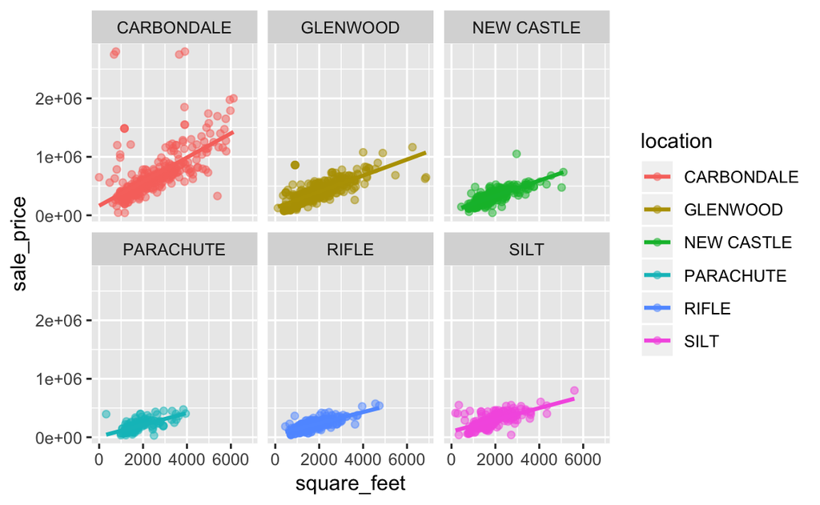

```r
ggplot(home_sales_fix, aes(square_feet, sale_price, color = location)) +
  geom_point(alpha = 0.5) +
  geom_smooth(method = "lm", se = FALSE) +
  facet_wrap(~ location)
```

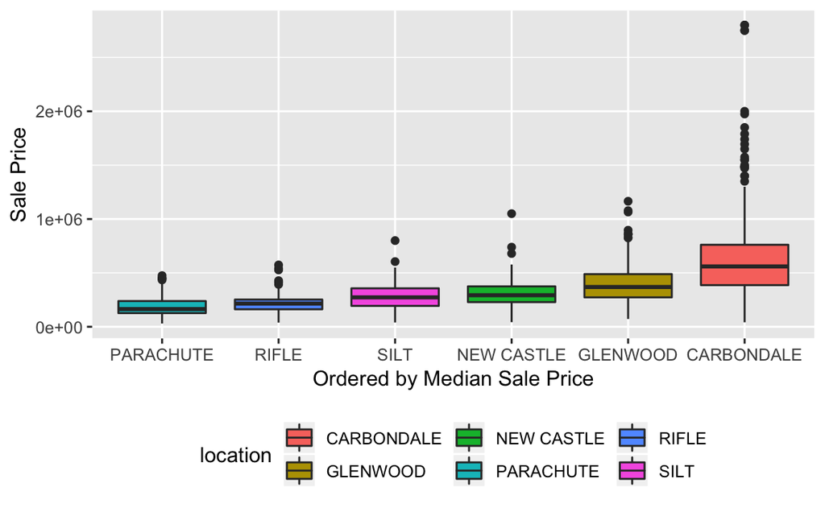

```r
ggplot(home_sales_fix,
       aes(x = reorder(location, sale_price, fun = median),
           y = sale_price, fill = location)) +
  geom_boxplot() + theme(legend.position = "bottom") +
  labs(x = "Ordered by Median Sale Price", y = "Sale Price")
```

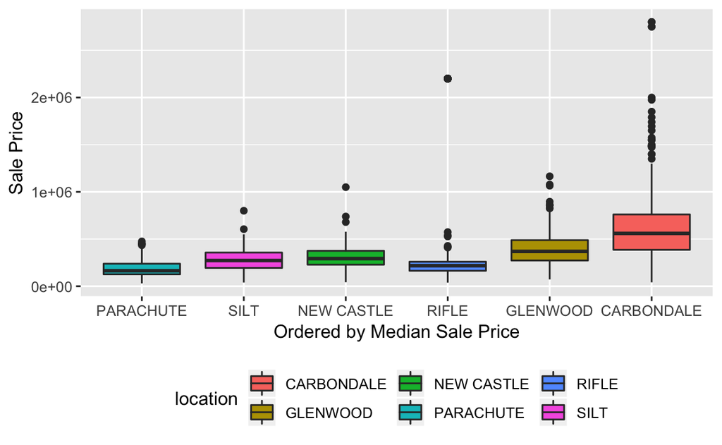

```r
ggplot(home_sales,
       aes(x = reorder(location, sale_price, fun = median),
           y = sale_price, fill = location)) +
  geom_boxplot() + theme(legend.position = "bottom") +
  labs(x = "Ordered by Median Sale Price", y = "Sale Price")
```

## Tidying wide datasets

```r
seattle_rain # Display Monthly Rain Gauge Accumulations for Seattle
```

```
## # A tibble: 175 x 18
##    Date   RG01  RG02  RG03  RG04  RG05  RG07  RG08  RG09 RG10_30  RG11
##    <chr> <dbl> <dbl> <dbl> <dbl> <dbl> <dbl> <dbl> <dbl>   <dbl> <dbl>
##  1 11/3…  2.43  3.36 2.88   2.48 0.78   2.49 2.57   2.93    3.25  2.38
##  2 12/3…  4.31  1.4  5.46   4.8  1.99   5.06 2.48   2.35    6.48  4.95
##  3 01/3…  6.55  7.35 5.84   6.48 7.57   4.47 7.39   7.31    5.42  6.58
##  4 02/2…  1.61  1.81 1.7    1.49 1.11   1.5  1.56   1.73    1.18  1.37
##  5 03/3…  5.01  5.88 3.12   5.01 5.09   5.15 5.14   5.01    5.68  4.01
##  6 04/3…  2.27  3.15 2.69   2.56 2.2    2.49 2.5    1.45    1.78  2.34
##  7 05/3…  0.91  1.49 1.51   1.4  0.43   1.59 0.98   0.93    0.83  1.45
##  8 06/3…  0.49  0.89 0.4    0.34 0.570  0.94 0.75   0.79    0.33  0.82
##  9 07/3…  0.12  0.18 0.16   0.51 0.17   0.89 0.21   0.06    0.14  0.2
## 10 08/3…  0.33  0.46 0.290  0.26 0.37   1.33 0.570  0.22    0.68  0.3
## # ... with 165 more rows, and 7 more variables: RG12 <dbl>, RG14 <dbl>,
## #   RG15 <dbl>, RG16 <dbl>, RG17 <dbl>, RG18 <dbl>, RG20_25 <dbl>
```

## `gather` columns `RG01` through `RG20_25`

```r
library(tidyr)
seattle_rain_tall <- seattle_rain %>%
  gather(RG01:RG20_25, key = rain_gauge, value = precip_inches)
seattle_rain_tall
```

```
## # A tibble: 2,975 x 3
##    Date       rain_gauge precip_inches
##    <chr>      <chr>              <dbl>
##  1 11/30/2002 RG01                2.43
##  2 12/31/2002 RG01                4.31
##  3 01/31/2003 RG01                6.55
##  4 02/28/2003 RG01                1.61
##  5 03/31/2003 RG01                5.01
##  6 04/30/2003 RG01                2.27
##  7 05/31/2003 RG01                0.91
##  8 06/30/2003 RG01                0.49
##  9 07/31/2003 RG01                0.12
## 10 08/31/2003 RG01                0.33
## # ... with 2,965 more rows
```

## `gather` all columns *except* `Date`

```r
library(tidyr)
seattle_rain_tall <- seattle_rain %>%
  gather(key = rain_gauge, value = precip_inches, -Date) # Same result as before!
seattle_rain_tall
```

```
## # A tibble: 2,975 x 3
##    Date       rain_gauge precip_inches
##    <chr>      <chr>              <dbl>
##  1 11/30/2002 RG01                2.43
##  2 12/31/2002 RG01                4.31
##  3 01/31/2003 RG01                6.55
##  4 02/28/2003 RG01                1.61
##  5 03/31/2003 RG01                5.01
##  6 04/30/2003 RG01                2.27
##  7 05/31/2003 RG01                0.91
##  8 06/30/2003 RG01                0.49
##  9 07/31/2003 RG01                0.12
## 10 08/31/2003 RG01                0.33
## # ... with 2,965 more rows
```

## Gathering in SQL

```sql
SELECT date, 'rg01' as rain_gauge, rg01 as precip_inches FROM seattle_rain UNION
SELECT date, 'rg02' as rain_gauge, rg02 as precip_inches FROM seattle_rain UNION
SELECT date, 'rg03' as rain_gauge, rg03 as precip_inches FROM seattle_rain UNION
SELECT date, 'rg04' as rain_gauge, rg04 as precip_inches FROM seattle_rain UNION
SELECT date, 'rg05' as rain_gauge, rg05 as precip_inches FROM seattle_rain UNION
SELECT date, 'rg07' as rain_gauge, rg07 as precip_inches FROM seattle_rain UNION
SELECT date, 'rg08' as rain_gauge, rg08 as precip_inches FROM seattle_rain UNION
SELECT date, 'rg09' as rain_gauge, rg09 as precip_inches FROM seattle_rain UNION
SELECT date, 'rg10_30' as rain_gauge, rg10_30 as precip_inches FROM seattle_rain UNION
SELECT date, 'rg11' as rain_gauge, rg11 as precip_inches FROM seattle_rain UNION
SELECT date, 'rg12' as rain_gauge, rg12 as precip_inches FROM seattle_rain UNION
SELECT date, 'rg14' as rain_gauge, rg14 as precip_inches FROM seattle_rain UNION
SELECT date, 'rg15' as rain_gauge, rg15 as precip_inches FROM seattle_rain UNION
SELECT date, 'rg16' as rain_gauge, rg16 as precip_inches FROM seattle_rain UNION
SELECT date, 'rg17' as rain_gauge, rg17 as precip_inches FROM seattle_rain UNION
SELECT date, 'rg18' as rain_gauge, rg18 as precip_inches FROM seattle_rain UNION
SELECT date, 'rg20_25' as rain_gauge, rg20_25 as precip_inches FROM seattle_rain
ORDER BY rain_gauge, date;
```

## Part 2: Many models with `purrr` and `broom`

## Linear model for Carbondale

```r
carbondale <- home_sales_fix %>%
  filter(location == "CARBONDALE")
model <- lm(sale_price ~ square_feet, data = carbondale)
summary(model)
```

```
##
## Call:
## lm(formula = sale_price ~ square_feet, data = carbondale)
##
## Residuals:
##     Min      1Q  Median      3Q     Max
## -944784 -117066  -61120   10307 2478788
##
## Coefficients:
##              Estimate Std. Error t value Pr(>|t|)
## (Intercept) 163668.19   34376.15   4.761 2.75e-06 ***
## square_feet    206.21      12.97  15.900  < 2e-16 ***
## ---
## Signif. codes:  0 '***' 0.001 '**' 0.01 '*' 0.05 '.' 0.1 ' ' 1
##
## Residual standard error: 309200 on 376 degrees of freedom
##   (1 observation deleted due to missingness)
## Multiple R-squared:  0.402,  Adjusted R-squared:  0.4005
## F-statistic: 252.8 on 1 and 376 DF,  p-value: < 2.2e-16
```

## Transform model into data frame with `broom`

```r
library(broom)
tidy(model)
```

```
## # A tibble: 2 x 5
##   term        estimate std.error statistic  p.value
##   <chr>          <dbl>     <dbl>     <dbl>    <dbl>
## 1 (Intercept)  163668.   34376.       4.76 2.75e- 6
## 2 square_feet     206.      13.0     15.9  6.66e-44
```

## `bind_rows` to combine models

```r
carbondale <- home_sales_fix %>%
  filter(location == "CARBONDALE")
model1 <- lm(sale_price ~ square_feet, data = carbondale)
glenwood <- home_sales_fix %>%
  filter(location == "GLENWOOD")
model2 <- lm(sale_price ~ square_feet, data = glenwood)
bind_rows(tidy(model1), tidy(model2))
```

```
## # A tibble: 4 x 5
##   term        estimate std.error statistic  p.value
##   <chr>          <dbl>     <dbl>     <dbl>    <dbl>
## 1 (Intercept)  163668.  34376.        4.76 2.75e- 6
## 2 square_feet     206.     13.0      15.9  6.66e-44
## 3 (Intercept)  128578.  11400.       11.3  4.42e-26
## 4 square_feet     138.      5.36     25.7  2.24e-89
```

## Step 1: `nest` by location

```r
home_sales_fix_models <- home_sales_fix %>%
  nest(-location)
home_sales_fix_models
```

```
## # A tibble: 6 x 2
##   location   data
##   <chr>      <list>
## 1 CARBONDALE <tibble [379 × 13]>
## 2 GLENWOOD   <tibble [441 × 13]>
## 3 NEW CASTLE <tibble [327 × 13]>
## 4 PARACHUTE  <tibble [202 × 13]>
## 5 RIFLE      <tibble [370 × 13]>
## 6 SILT       <tibble [225 × 13]>
```

## Alternate syntax used by Wickham

```r
home_sales_fix %>%
  group_by(location) %>%
  nest()
```

```
## # A tibble: 6 x 2
##   location   data
##   <chr>      <list>
## 1 CARBONDALE <tibble [379 × 13]>
## 2 GLENWOOD   <tibble [441 × 13]>
## 3 NEW CASTLE <tibble [327 × 13]>
## 4 PARACHUTE  <tibble [202 × 13]>
## 5 RIFLE      <tibble [370 × 13]>
## 6 SILT       <tibble [225 × 13]>
```

## Examine the data for New Castle

```r
home_sales_fix_models$data[[3]]
```

```
## # A tibble: 327 x 13
##    account parcel_number reception sale_date sale_price situs_address
##    <chr>   <chr>         <chr>     <chr>          <dbl> <chr>
##  1 R044215 212331109026  860557    3/16/2015     145000 000176 N 4TH…
##  2 R380139 212331107012  868155    9/16/2015     195000 000146 N 2ND…
##  3 R043923 212331110031  866949    8/14/2015     162000 000161 N 4TH…
##  4 R380402 212331226003  875582    4/4/2016      205000 000222 N 7TH…
##  5 R040070 212325300002  872566    1/13/2016     375000 000570 137 C…
##  6 R380215 212331223016  861672    4/17/2015     176900 000640 W MAI…
##  7 R015027 218106400058  858833    1/30/2015     255000 005341 214 C…
##  8 R170410 218332101001  872474    1/13/2016     485000 008149 312 C…
##  9 R005504 212330320001  866365    8/4/2015      268500 000601 LARIA…
## 10 R005511 212330320008  878740    6/23/2016     299000 000623 LARIA…
## # ... with 317 more rows, and 7 more variables: architectural_style <chr>,
## #   year_built <dbl>, bedrooms <dbl>, baths <dbl>, square_feet <dbl>,
## #   legal <chr>, classification <chr>
```

## Unnesting returns to original

```r
unnest(home_sales_fix_models)
```

```
## # A tibble: 1,944 x 14
##    location account parcel_number reception sale_date sale_price
##    <chr>    <chr>   <chr>         <chr>     <chr>          <dbl>
##  1 CARBOND… R340967 239334401005  879240    6/29/2016     650000
##  2 CARBOND… R340073 239334200010  870778    11/24/20…     560000
##  3 CARBOND… R112063 239335100057  869383    10/13/20…    2750000
##  4 CARBOND… R580140 239334366004  857328    12/18/20…     630500
##  5 CARBOND… R043949 239120300276  853541    9/12/2014    2800000
##  6 CARBOND… R011301 239120300057  868354    9/21/2015     785000
##  7 CARBOND… R011415 239325100148  861479    4/10/2015    1200000
##  8 CARBOND… R005930 246304125013  875431    3/24/2016    1040000
##  9 CARBOND… R040419 246303100026  865422    7/13/2015     340000
## 10 CARBOND… R041666 239334268001  868224    9/15/2015     395000
## # ... with 1,934 more rows, and 8 more variables: situs_address <chr>,
## #   architectural_style <chr>, year_built <dbl>, bedrooms <dbl>,
## #   baths <dbl>, square_feet <dbl>, legal <chr>, classification <chr>
```

## Step 2: `map()` to fit lm to each dataset

```r
library(purrr)
home_sales_fix_models <- home_sales_fix %>%
  nest(-location) %>%
  mutate(models = map(data, ~lm(sale_price ~ square_feet, .)))
  # data has been passed into lm through map function
  # dot "." is used for data in the lm call
home_sales_fix_models
```

```
## # A tibble: 6 x 3
##   location   data                models
##   <chr>      <list>              <list>
## 1 CARBONDALE <tibble [379 × 13]> <S3: lm>
## 2 GLENWOOD   <tibble [441 × 13]> <S3: lm>
## 3 NEW CASTLE <tibble [327 × 13]> <S3: lm>
## 4 PARACHUTE  <tibble [202 × 13]> <S3: lm>
## 5 RIFLE      <tibble [370 × 13]> <S3: lm>
## 6 SILT       <tibble [225 × 13]> <S3: lm>
```

## Examine the model for New Castle

```r
home_sales_fix_models$models[[3]]
```

```
##
## Call:
## lm(formula = sale_price ~ square_feet, data = .)
##
## Coefficients:
## (Intercept)  square_feet
##     70045.8        130.7
```

## Step 3: Use `map()` to tidy each model

```r
home_sales_fix_models <- home_sales_fix %>%
  nest(-location) %>%
  mutate(models = map(data, ~lm(sale_price ~ square_feet, .))) %>%
  mutate(tidied = map(models, tidy))
home_sales_fix_models
```

```
## # A tibble: 6 x 4
##   location   data                models   tidied
##   <chr>      <list>              <list>   <list>
## 1 CARBONDALE <tibble [379 × 13]> <S3: lm> <tibble [2 × 5]>
## 2 GLENWOOD   <tibble [441 × 13]> <S3: lm> <tibble [2 × 5]>
## 3 NEW CASTLE <tibble [327 × 13]> <S3: lm> <tibble [2 × 5]>
## 4 PARACHUTE  <tibble [202 × 13]> <S3: lm> <tibble [2 × 5]>
## 5 RIFLE      <tibble [370 × 13]> <S3: lm> <tibble [2 × 5]>
## 6 SILT       <tibble [225 × 13]> <S3: lm> <tibble [2 × 5]>
```

## Examine tidy model for New Castle

```r
home_sales_fix_models$tidied[[3]]
```

```
## # A tibble: 2 x 5
##   term        estimate std.error statistic  p.value
##   <chr>          <dbl>     <dbl>     <dbl>    <dbl>
## 1 (Intercept)   70046.  11041.        6.34 7.49e-10
## 2 square_feet     131.      5.68     23.0  3.65e-70
```

## Step 4: `unnest` to tidy table of coefficients

```r
location_coeffs <- home_sales_fix %>%
  nest(-location) %>%
  mutate(models = map(data, ~lm(sale_price ~ square_feet, .))) %>%
  mutate(tidied = map(models, tidy)) %>%
  unnest(tidied)
location_coeffs
```

```
## # A tibble: 12 x 6
##    location   term        estimate std.error statistic  p.value
##    <chr>      <chr>          <dbl>     <dbl>     <dbl>    <dbl>
##  1 CARBONDALE (Intercept) 163668.   34376.       4.76  2.75e- 6
##  2 CARBONDALE square_feet    206.      13.0     15.9   6.66e-44
##  3 GLENWOOD   (Intercept) 128578.   11400.      11.3   4.42e-26
##  4 GLENWOOD   square_feet    138.       5.36    25.7   2.24e-89
##  5 NEW CASTLE (Intercept)  70046.   11041.       6.34  7.49e-10
##  6 NEW CASTLE square_feet    131.       5.68    23.0   3.65e-70
##  7 PARACHUTE  (Intercept)  11651.   14526.       0.802 4.23e- 1
##  8 PARACHUTE  square_feet    101.       8.07    12.5   9.75e-27
##  9 RIFLE      (Intercept)  46757.    8363.       5.59  4.41e- 8
## 10 RIFLE      square_feet     95.9      4.64    20.7   1.36e-63
## 11 SILT       (Intercept)  98978.   15629.       6.33  1.31e- 9
## 12 SILT       square_feet    100.       7.87    12.7   3.30e-28
```

## Location slopes

```r
location_slopes <-  location_coeffs %>%
  filter(term == "square_feet")%>%
  arrange(estimate)
location_slopes
```

```
## # A tibble: 6 x 6
##   location   term        estimate std.error statistic  p.value
##   <chr>      <chr>          <dbl>     <dbl>     <dbl>    <dbl>
## 1 RIFLE      square_feet     95.9      4.64      20.7 1.36e-63
## 2 SILT       square_feet    100.       7.87      12.7 3.30e-28
## 3 PARACHUTE  square_feet    101.       8.07      12.5 9.75e-27
## 4 NEW CASTLE square_feet    131.       5.68      23.0 3.65e-70
## 5 GLENWOOD   square_feet    138.       5.36      25.7 2.24e-89
## 6 CARBONDALE square_feet    206.      13.0       15.9 6.66e-44
```

## Compute residuals for Rifle, pre-fix

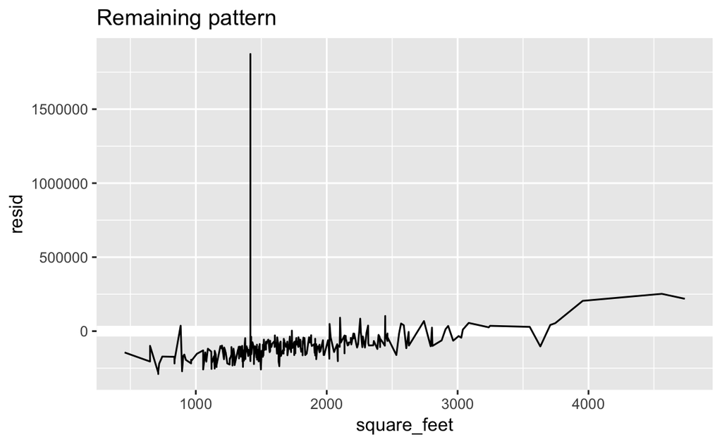

```r
library(modelr) # for add_residuals function
rifle <- filter(home_sales, location == "RIFLE")
rifle_model <- lm(sale_price ~ square_feet, data = rifle)
rifle %>%
  add_residuals(rifle_model) %>%
  ggplot(aes(square_feet, resid)) + # new resid column
  geom_hline(yintercept = 0, color = "white", size = 3) +
  geom_line() +
  ggtitle("Remaining pattern")
```

## Compute residuals for Rifle, fixed

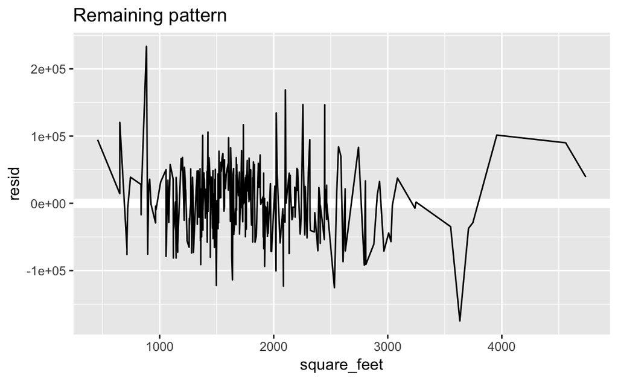

```r
rifle <- filter(home_sales_fix, location == "RIFLE")
rifle_model <- lm(sale_price ~ square_feet, data = rifle)
rifle %>%
  add_residuals(rifle_model) %>%
  ggplot(aes(square_feet, resid)) +
  geom_hline(yintercept = 0, color = "white", size = 3) +
  geom_line() +
  ggtitle("Remaining pattern")
```

## Compute residuals

```r
# Call add_residuals() with each model-data pair:
home_sales_fix_models <- home_sales_fix_models %>%
  # Add 'resid' column to 'data' df list with mutate
  mutate(data = map2(data, models, add_residuals))
home_sales_fix_models
```

```
## # A tibble: 6 x 4
##   location   data                models   tidied
##   <chr>      <list>              <list>   <list>
## 1 CARBONDALE <tibble [379 × 14]> <S3: lm> <tibble [2 × 5]>
## 2 GLENWOOD   <tibble [441 × 14]> <S3: lm> <tibble [2 × 5]>
## 3 NEW CASTLE <tibble [327 × 14]> <S3: lm> <tibble [2 × 5]>
## 4 PARACHUTE  <tibble [202 × 14]> <S3: lm> <tibble [2 × 5]>
## 5 RIFLE      <tibble [370 × 14]> <S3: lm> <tibble [2 × 5]>
## 6 SILT       <tibble [225 × 14]> <S3: lm> <tibble [2 × 5]>
```

## Examine residuals for New Castle

```r
home_sales_fix_models$data[[3]] %>%
  select(sale_price, square_feet, resid)
```

```
## # A tibble: 327 x 3
##    sale_price square_feet    resid
##         <dbl>       <dbl>    <dbl>
##  1     145000         450   16124.
##  2     195000         768   24551.
##  3     162000         800  -12632.
##  4     205000         864   22001.
##  5     375000         900  187294.
##  6     176900         947  -16950.
##  7     255000        1064   45854.
##  8     485000        1076  274285.
##  9     268500        1148   48372.
## 10     299000        1148   78872.
## # ... with 317 more rows
```

## `unnest` list of dataframes to plot resids

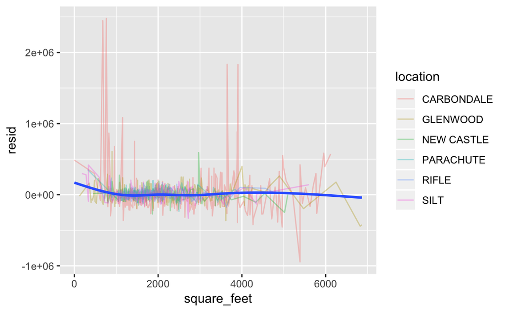

```r
resids <- unnest(home_sales_fix_models, data)
resids %>%
  ggplot(aes(square_feet, resid)) +
  geom_line(aes(group = location, color=location), alpha = 1 / 3) +
  geom_smooth(se = FALSE)
```

## Or facet by location

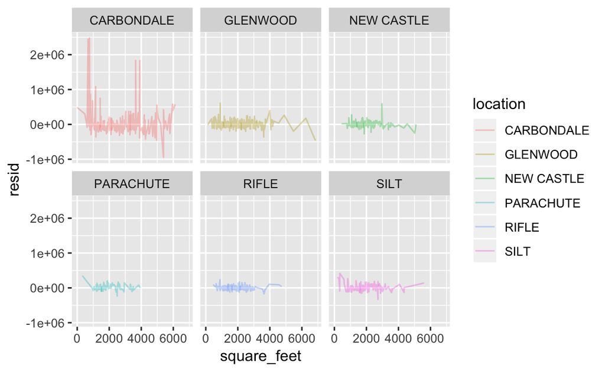

```r
resids %>%
  ggplot(aes(square_feet, resid, color = location)) +
  geom_line(alpha = 1 / 3) +
  facet_wrap(~ location)
```

## Pipe it all together!

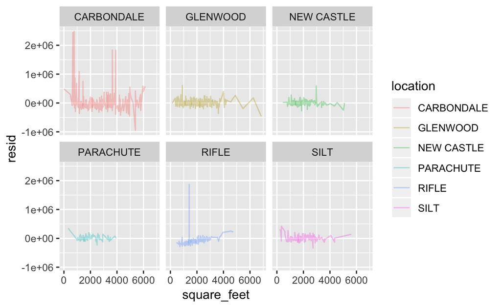

```r
home_sales %>% # Original dataset for Rifle with errors!
  nest(-location) %>%
  mutate(models = map(data, ~lm(sale_price ~ square_feet, .))) %>%
  mutate(data = map2(data, models, add_residuals)) %>%
  unnest(data) %>%
  ggplot(aes(square_feet, resid, color = location)) +
  geom_line(alpha = 1 / 3) +
  facet_wrap(~ location)
```